# ADSP 32018 - NLP - Assignment 1

### Assignment 1

#### Author: Aashish Singh

You are working on a project to promote the food safety in Chicago. Your goal is to identify the top-10 most frequent causes of failed food inspections in Chicago and effectively present them to your boss.

You can either use attached started notebook to read the data from API:

NLP_Assignment_1_Starter.ipynb Download NLP_Assignment_1_Starter.ipynb

Or download the CSV from this link: Links to an external site.https://data.cityofchicago.org/Health-Human-Services/Food-Inspections/4ijn-s7e5

```python
import pandas as pd
import requests
import re
from collections import Counter
import seaborn as sns
import matplotlib.pyplot as plt
```

```python
import requests

def get_total_count(url):
    try:
        response = requests.get(url)
        response.raise_for_status()  # Check if the request was successful
        if response.text:  # Check if the response is not empty
            return response.json()
        else:
            print("The response is empty.")
            return None
    except requests.exceptions.HTTPError as http_err:
        print(f"HTTP error occurred: {http_err}")
    except requests.exceptions.RequestException as req_err:
        print(f"Request error occurred: {req_err}")
    except requests.exceptions.JSONDecodeError as json_err:
        print(f"JSON decode error occurred: {json_err}")
    return None

# Example usage
url = 'https://data.cityofchicago.org/resource/cwig-ma7x.json'
total_count = get_total_count(url)
print(total_count)
```

```
[{'inspection_id': '2596320', 'dba_name': 'TACARIA SEVEN BROTHERS', 'aka_name': 'TAQUERIA 7 HERMANOS', 'license_': '83740', 'facility_type': 'Restaurant', 'risk': 'Risk 1 (High)', 'address': '3755 S KEDZIE AVE ', 'city': 'CHICAGO', 'state': 'IL', 'zip': '60632', 'inspection_date': '2024-06-14T00:00:…
```

```python
%%time

# Define the API endpoint and parameters
url = "https://data.cityofchicago.org/resource/cwig-ma7x.json"

# Fetch the total count of records
def get_total_count(url):
    params = {
        "$select": "count(*)"
    }
    response = requests.get(url, params=params)
    data = response.json()
    return int(data[0]['count'])

total_count = get_total_count(url)
print(f"Total number of records available: {total_count:,.0f}")
```

```
Total number of records available: 273,851
CPU times: user 17.5 ms, sys: 2.91 ms, total: 20.4 ms
Wall time: 398 ms
```

```python
%%time

# Fetch data and load it into a pandas DataFrame
def fetch_data(url, params):
    response = requests.get(url, params=params)
    data = response.json()
    return pd.DataFrame(data)

# Set the limit parameter equal to the number of available records
params = {
    "$limit": total_count
}

# Fetch the data and load it into a DataFrame
df = fetch_data(url, params)

print(f'Number of records retrieved: {df.shape[0]:,.0f}')
```

```
Number of records retrieved: 273,851
CPU times: user 8.95 s, sys: 1.4 s, total: 10.3 s
Wall time: 45.8 s
```

```python
df.head(5)
```

|  | inspection_id | dba_name | aka_name | license_ | facility_type | risk | address | city | state | zip | ... | results | violations | latitude | longitude | location | :@computed_region_awaf_s7ux | :@computed_region_6mkv_f3dw | :@computed_region_vrxf_vc4k | :@computed_region_bdys_3d7i | :@computed_region_43wa_7qmu |
| --- | --- | --- | --- | --- | --- | --- | --- | --- | --- | --- | --- | --- | --- | --- | --- | --- | --- | --- | --- | --- | --- |
| 0 | 2596307 | TARGET STORE T-3402 | TARGET STORE T-3402 | 2786471 | Grocery Store | Risk 2 (Medium) | 630 N LA SALLE DR | CHICAGO | IL | 60654 | ... | Pass | 55. PHYSICAL FACILITIES INSTALLED, MAINTAINED ... | 41.89324477386844 | -87.63278670384113 | {'type': 'Point', 'coordinates': [-87.63278670... | 22 | 4446 | 37 | 670 | 36 |
| 1 | 2596320 | TACARIA SEVEN BROTHERS | TAQUERIA 7 HERMANOS | 83740 | Restaurant | Risk 1 (High) | 3755 S KEDZIE AVE | CHICAGO | IL | 60632 | ... | Pass | 44. UTENSILS, EQUIPMENT & LINENS: PROPERLY STO... | 41.8244517773573 | -87.70430279705077 | {'type': 'Point', 'coordinates': [-87.70430279... | 29 | 22248 | 55 | 639 | 1 |
| 2 | 2596319 | GANGNAM MARKET | GANGNAM MARKET | 2862860 | Grocery Store | Risk 1 (High) | 1001 W CHICAGO AVE | CHICAGO | IL | 60642 | ... | Pass | 49. NON-FOOD/FOOD CONTACT SURFACES CLEAN - Com... | 41.89619832858024 | -87.65267972770035 | {'type': 'Point', 'coordinates': [-87.65267972... | 41 | 22620 | 25 | 522 | 46 |
| 3 | 2596317 | JANIK'S CAFE | JANIK'S CAFE | 1356941 | Restaurant | Risk 1 (High) | 2011 W DIVISION ST | CHICAGO | IL | 60622 | ... | Pass w/ Conditions | 22. PROPER COLD HOLDING TEMPERATURES - Comment... | 41.90307250619249 | -87.67775518394137 | {'type': 'Point', 'coordinates': [-87.67775518... | 24 | 21560 | 25 | 476 | 41 |
| 4 | 2596298 | DUFFY'S TAVERN & GRILLE | DUFFY'S TAVERN & GRILLE | 2158028 | Restaurant | Risk 1 (High) | 420-422 W DIVERSEY PKWY | CHICAGO | IL | 60614 | ... | Out of Business | NaN | 41.93300409973139 | -87.64018629087145 | {'type': 'Point', 'coordinates': [-87.64018629... | 38 | 21190 | 57 | 153 | 25 |

5 rows × 22 columns

```python
df.shape
```

```
(273851, 22)
```

#### 1. Select only the records corresponding to failed inspection (see "results" column)

```python
failed_inspections = df[df['results'] == 'Fail']
failed_inspections.shape
```

```
(53545, 22)
```

#### 2. Clean the data, making sure that there are no NaNs in "violations" column

```python
failed_inspections_cleaned = failed_inspections.dropna(subset=['violations'])
failed_inspections_cleaned.shape
```

```
(50070, 22)
```

```python
failed_inspections_cleaned.head()
```

|  | inspection_id | dba_name | aka_name | license_ | facility_type | risk | address | city | state | zip | ... | results | violations | latitude | longitude | location | :@computed_region_awaf_s7ux | :@computed_region_6mkv_f3dw | :@computed_region_vrxf_vc4k | :@computed_region_bdys_3d7i | :@computed_region_43wa_7qmu |
| --- | --- | --- | --- | --- | --- | --- | --- | --- | --- | --- | --- | --- | --- | --- | --- | --- | --- | --- | --- | --- | --- |
| 9 | 2596204 | 101 CLUB | 101 CLUB PATIO BAR & GRILL | 2956667 | Restaurant | Risk 3 (Low) | 101 E ERIE ST | CHICAGO | IL | 60611 | ... | Fail | 39. CONTAMINATION PREVENTED DURING FOOD PREPAR... | 41.89400968711272 | -87.62536771830537 | {'type': 'Point', 'coordinates': [-87.62536771... | 22 | 21182 | 37 | 626 | 36 |
| 20 | 2596274 | STANLEY'S GRILL | STANLEY'S GRILL | 1622034 | Restaurant | Risk 1 (High) | 1543 N ELSTON AVE | CHICAGO | IL | 60642 | ... | Fail | 38. INSECTS, RODENTS, & ANIMALS NOT PRESENT - ... | 41.9102628778286 | -87.66170856673062 | {'type': 'Point', 'coordinates': [-87.66170856... | 16 | 22620 | 25 | 109 | 46 |
| 34 | 2596211 | VOID CHICAGO | VOID CHICAGO | 2886461 | Restaurant | Risk 1 (High) | 2937 N MILWAUKEE AVE | CHICAGO | IL | 60618 | ... | Fail | 10. ADEQUATE HANDWASHING SINKS PROPERLY SUPPLI... | 41.934705675709715 | -87.7164143561994 | {'type': 'Point', 'coordinates': [-87.71641435... | 15 | 21538 | 22 | 55 | 12 |
| 36 | 2596234 | UN AMOR | UN AMOR | 2934629 | Restaurant | Risk 1 (High) | 1450 W CHICAGO AVE | CHICAGO | IL | 60642 | ... | Fail | 2. CITY OF CHICAGO FOOD SERVICE SANITATION CER... | 41.89622764512234 | -87.6644351787337 | {'type': 'Point', 'coordinates': [-87.66443517... | 41 | 22620 | 25 | 484 | 41 |
| 39 | 2596206 | LA FIESTA | LA FIESTA | 2856707 | Restaurant | Risk 1 (High) | 4248 S ARCHER AVE | CHICAGO | IL | 60632 | ... | Fail | 48. WAREWASHING FACILITIES: INSTALLED, MAINTAI... | 41.81629173762001 | -87.7008897812118 | {'type': 'Point', 'coordinates': [-87.70088978... | 49 | 22248 | 55 | 156 | 3 |

5 rows × 22 columns

#### 3. "Violations" column lists the reasons for inspection failure. Those reasons are separated by "|". Each reason consists of a regulation code, regulation description, and comments describing how the regulation was violated.

```python
failed_inspections_cleaned['violations'].unique()[2]
```

```
'10. ADEQUATE HANDWASHING SINKS PROPERLY SUPPLIED AND ACCESSIBLE - Comments: FOUND NO HAND SINK AT PASTA PREPARATION AREAS.PRIORITY VIOLATION.NO CITATION ISSUED.7-38-030C.MUST PROVIDE. | 58. ALLERGEN TRAINING AS REQUIRED - Comments: FOUND SANITATION MANAGER WITH NO ALLERGEN TRAINING.MUST PROVIDE.'
```

#### 4. Using regular expression, parse "violations" column to select only regulation descriptions, no code or comments

```python
# Let's define a function that select only description and no code / comment
def extract_descriptions(text):
    matches = re.findall(r'\d+\.\s*([^|-]+)', text)
    # Saw that we were getting MUST PROVIDE incorrectly. Modified below to remove those.
    cleaned_matches = [re.split(r'\s-\sComments:|MUST PROVIDE', match)[0].strip() for match in matches]
    # Remove any blanks / empty values
    cleaned_matches = list(filter(None, cleaned_matches))
    return cleaned_matches

failed_inspections_cleaned['violation_descriptions'] = failed_inspections_cleaned['violations'].apply(extract_descriptions)
failed_inspections_cleaned['violation_descriptions'].apply(tuple).unique()[2]
```

```
('ADEQUATE HANDWASHING SINKS PROPERLY SUPPLIED AND ACCESSIBLE',
 'ALLERGEN TRAINING AS REQUIRED')
```

#### 5. Count how many times each regulation description occurred in the table and visualize top-10 the most frequent regulation descriptions

```python
# Flatten the list of violation descriptions and display the top 10 most frequent regulation descriptions
violation_descriptions = [desc for sublist in failed_inspections_cleaned['violation_descriptions'] for desc in sublist]
description_counts = Counter(violation_descriptions)
top_10_descriptions = pd.DataFrame(description_counts.most_common(10), columns=['Violation Description', 'Count'])
print(top_10_descriptions)
```

```
                               Violation Description  Count
0                                       FOOD AND NON  31464
1  PHYSICAL FACILITIES INSTALLED, MAINTAINED & CLEAN  20666
2  FLOORS: CONSTRUCTED PER CODE, CLEANED, GOOD RE...  19371
3  WALLS, CEILINGS, ATTACHED EQUIPMENT CONSTRUCTE...  18257
4  NO EVIDENCE OF RODENT OR INSECT OUTER OPENINGS...  16432
5  VENTILATION: ROOMS AND EQUIPMENT VENTED AS REQ...  15529
6            INSECTS, RODENTS, & ANIMALS NOT PRESENT  11495
7  ADEQUATE HANDWASHING SINKS PROPERLY SUPPLIED A...  10934
8  PREMISES MAINTAINED FREE OF LITTER, UNNECESSAR...  10667
9                                         FOOD & NON   9089
```

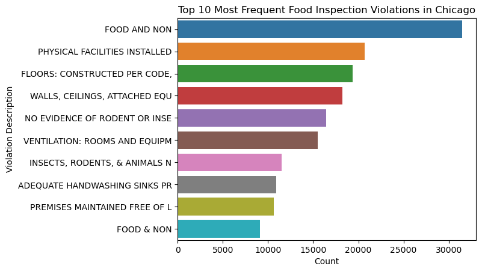

```python
# The description made it hard for us to see the graph so we reduce length of violation description
max_length = 29
top_10_descriptions['Violation Description'] = top_10_descriptions['Violation Description'].apply(lambda x: x[:max_length])

# Visualize the top 10 most frequent regulation descriptions
sns.barplot(x='Count', y='Violation Description', data=top_10_descriptions)
plt.title('Top 10 Most Frequent Food Inspection Violations in Chicago')
plt.show()
```

#### 6. Identify whether any of these restaurants are repeat offenders (explore a combination of License; Business Name and Address variables to determine what is the best way to uniquely identify a business) and whether the violations are the same or different for these repeat offenses

```python
# Let's identify restaurants that are repeat offenders
repeat_offenders = failed_inspections_cleaned.groupby(['license_', 'dba_name', 'address']).size().reset_index(name='offense_count')
repeat_offenders = repeat_offenders[repeat_offenders['offense_count'] > 1]

repeat_offenders.sort_values(by='offense_count', ascending=False)

# Yes, there are restaurants that are repeat offenders as can be seen in the table
```

|  | license_ | dba_name | address | offense_count |
| --- | --- | --- | --- | --- |
| 329 | 1095992 | LAS ISLAS MARIAS | 4770 W GRAND AVE | 22 |
| 21038 | 39623 | LUMES PANCAKE HOUSE | 11601 S WESTERN AVE | 21 |
| 7963 | 2125165 | LUIGI'S PIZZA BY THE SLICE, INC | 4212 W MADISON ST | 21 |
| 21696 | 60184 | TAQUERIA EL RANCHITO | 2829 N MILWAUKEE AVE | 20 |
| 3969 | 1909713 | IYANZE | 4623-4627 N BROADWAY | 20 |
| ... | ... | ... | ... | ... |
| 9985 | 2222307 | AURORA CHICAGO LAKESHORE | 4720 N CLARENDON | 2 |
| 9983 | 2222223 | COMPASS BAR | 433 W DIVERSEY PKWY | 2 |
| 9981 | 2222211 | HUSKY HOG BBQ, LLC | 324 N Leavitt | 2 |
| 9967 | 2221570 | NEVERIA LLUVIA,LIMITED | 3006 E 88TH ST | 2 |
| 10511 | 2256167 | Q SAZON MEXICAN RESTAURANT | 8451 S PULASKI RD | 2 |

11206 rows × 4 columns

```python
repeat_offenders_merged = failed_inspections_cleaned.merge(repeat_offenders, on=['license_', 'dba_name', 'address'], how='inner')
repeat_offenders_merged

# Let's see what violations are repeated by these restaurants
flattened_data = []
for index, row in repeat_offenders_merged.iterrows():
    license_ = row['license_']
    dba_name = row['dba_name']
    address = row['address']
    for violation in row['violation_descriptions']:
        flattened_data.append({
            'license_': license_,
            'dba_name': dba_name,
            'address': address,
            'violation_description': violation
        })

# Create a DataFrame from the flattened data
flattened_df = pd.DataFrame(flattened_data)

# Count the occurrences of each violation description
violation_counts = flattened_df.groupby(['license_', 'dba_name', 'address', 'violation_description']).size().reset_index(name='offense_count')
violation_counts.sort_values(by= ['address', 'dba_name', 'offense_count'], ascending=[True, True, False])

# We can see there are some violations that are same for these repeat offenses and some are different
```

|  | license_ | dba_name | address | violation_description | offense_count |
| --- | --- | --- | --- | --- | --- |
| 46597 | 1938179 | SUBWAY | 1 E 83RD ST | PHYSICAL FACILITIES INSTALLED, MAINTAINED & CLEAN | 8 |
| 46582 | 1938179 | SUBWAY | 1 E 83RD ST | FLOORS: CONSTRUCTED PER CODE, CLEANED, GOOD RE... | 5 |
| 46589 | 1938179 | SUBWAY | 1 E 83RD ST | INSECTS, RODENTS, & ANIMALS NOT PRESENT | 5 |
| 46607 | 1938179 | SUBWAY | 1 E 83RD ST | VENTILATION: ROOMS AND EQUIPMENT VENTED AS REQ... | 5 |
| 46585 | 1938179 | SUBWAY | 1 E 83RD ST | FOOD AND NON | 4 |
| ... | ... | ... | ... | ... | ... |
| 18851 | 149 | FOX'S BEVERLY PUB | 9956 S WESTERN AVE | PROPER DATE MARKING AND DISPOSITION | 1 |
| 18852 | 149 | FOX'S BEVERLY PUB | 9956 S WESTERN AVE | SANITIZING RINSE FOR EQUIPMENT AND UTENSILS: ... | 1 |
| 18853 | 149 | FOX'S BEVERLY PUB | 9956 S WESTERN AVE | SINGLE | 1 |
| 18854 | 149 | FOX'S BEVERLY PUB | 9956 S WESTERN AVE | VENTILATION: ROOMS AND EQUIPMENT VENTED AS REQ... | 1 |
| 18856 | 149 | FOX'S BEVERLY PUB | 9956 S WESTERN AVE | WIPING CLOTHS: PROPERLY USED & STORED | 1 |

199257 rows × 5 columns

#### 7. Review the restaurants "Out of Business", is there an extended history of prior violations for these closed restaurants?

```python
# Let's find out all the "Out of Business" restaurants
out_of_business_restaurants = df[(df['results'] == 'Out of Business') & (df['facility_type'] == 'Restaurant')]
out_of_business_restaurants
```

|  | inspection_id | dba_name | aka_name | license_ | facility_type | risk | address | city | state | zip | ... | results | violations | latitude | longitude | location | :@computed_region_awaf_s7ux | :@computed_region_6mkv_f3dw | :@computed_region_vrxf_vc4k | :@computed_region_bdys_3d7i | :@computed_region_43wa_7qmu |
| --- | --- | --- | --- | --- | --- | --- | --- | --- | --- | --- | --- | --- | --- | --- | --- | --- | --- | --- | --- | --- | --- |
| 4 | 2596298 | DUFFY'S TAVERN & GRILLE | DUFFY'S TAVERN & GRILLE | 2158028 | Restaurant | Risk 1 (High) | 420-422 W DIVERSEY PKWY | CHICAGO | IL | 60614 | ... | Out of Business | NaN | 41.93300409973139 | -87.64018629087145 | {'type': 'Point', 'coordinates': [-87.64018629... | 38 | 21190 | 57 | 153 | 25 |
| 22 | 2596276 | BIGGS AT THE BRIDGE | JIMMYS | 2817545 | Restaurant | Risk 1 (High) | 6659 S CICERO AVE | CHICAGO | IL | 60638 | ... | Out of Business | NaN | 41.77122269655533 | -87.74191038750742 | {'type': 'Point', 'coordinates': [-87.74191038... | 23 | 22268 | 62 | 338 | 15 |
| 25 | 2596267 | MINGHIN JAPANESE | MINGHIN CUISINE | 2670192 | Restaurant | Risk 1 (High) | 1232-1234 S MICHIGAN AVE | CHICAGO | IL | 60605 | ... | Out of Business | NaN | 41.86654115432376 | -87.62428056789263 | {'type': 'Point', 'coordinates': [-87.62428056... | 48 | 14913 | 34 | 374 | 9 |
| 51 | 2596254 | KFC | KFC | 2911782 | Restaurant | Risk 1 (High) | 7508 S LAFAYETTE AVE | CHICAGO | IL | 60620 | ... | Out of Business | NaN | 41.75784542130043 | -87.6265109472516 | {'type': 'Point', 'coordinates': [-87.62651094... | 31 | 21554 | 67 | 495 | 32 |
| 150 | 2596130 | SAM & GERTIE'S / PORFIRIO D. F. | LONGACRE | 2609722 | Restaurant | Risk 1 (High) | 1303-1309 W WILSON AVE | CHICAGO | IL | 60640 | ... | Out of Business | NaN | 41.96521814498499 | -87.66258555303558 | {'type': 'Point', 'coordinates': [-87.66258555... | 37 | 22616 | 31 | 611 | 39 |
| ... | ... | ... | ... | ... | ... | ... | ... | ... | ... | ... | ... | ... | ... | ... | ... | ... | ... | ... | ... | ... | ... |
| 265000 | 154396 | EMILIO'S-TAPAS CHICAGO | EMILIO'S-TAPAS CHICAGO | 38474 | Restaurant | Risk 1 (High) | 444 W FULLERTON PKWY | CHICAGO | IL | 60614 | ... | Out of Business | NaN | 41.92568726351064 | -87.64095823958841 | {'type': 'Point', 'coordinates': [-87.64095823... | 51 | 21190 | 68 | 185 | 34 |
| 265056 | 124467 | LAFERIR INTERNET CAFE & GIFT SHOP, INC | LAFERIR INTERNET CAFE & GIFT SHOP, INC | 2021669 | Restaurant | Risk 2 (Medium) | 4942 N PULASKI RD | CHICAGO | IL | 60630 | ... | Out of Business | NaN | 41.97133863581661 | -87.72826479944104 | {'type': 'Point', 'coordinates': [-87.72826479... | 28 | 21869 | 14 | 751 | 38 |
| 265446 | 251140 | SANCHEZ TACOS | SANCHEZ TACOS | 1442295 | Restaurant | Risk 1 (High) | 4001 W OGDEN | CHICAGO | IL | 60623 | ... | Out of Business | NaN | 41.850957959367854 | -87.72477522322536 | {'type': 'Point', 'coordinates': [-87.72477522... | 14 | 21569 | 30 | 125 | 28 |
| 266085 | 112437 | SALAD CREATIONS | SALAD CREATIONS | 1848010 | Restaurant | Risk 2 (Medium) | 56 E JACKSON BLVD | CHICAGO | IL | 60604 | ... | Out of Business | NaN | 41.878367290653976 | -87.62558159573472 | {'type': 'Point', 'coordinates': [-87.62558159... | 22 | 14912 | 38 | 367 | 36 |
| 269136 | 231327 | MOUNTAIN VIEW CHEF INC | MOUNTAIN VIEW CHEF INC | 1145427 | Restaurant | Risk 1 (High) | 2168-2170 S ARCHER AVE | CHICAGO | IL | 60616 | ... | Out of Business | NaN | 41.85316719933144 | -87.63446102872312 | {'type': 'Point', 'coordinates': [-87.63446102... | 8 | 21194 | 35 | 3 | 26 |

13145 rows × 22 columns

```python
# Let's then use this "Out of Business" restaurants data and get all of the past violations data
# which we can get from previously created repeat_offenders data
out_of_business_prior_violations = out_of_business_restaurants.merge(repeat_offenders, on=['license_', 'dba_name', 'address'], how='inner')
out_of_business_prior_violations.sort_values(by='offense_count', ascending=False)

# Yes there does seem to be some restaraunts that have multiple prior violations that are now "Out of Business"
# 3762/13145 = ~29% of data has prior violations
```

|  | inspection_id | dba_name | aka_name | license_ | facility_type | risk | address | city | state | zip | ... | violations | latitude | longitude | location | :@computed_region_awaf_s7ux | :@computed_region_6mkv_f3dw | :@computed_region_vrxf_vc4k | :@computed_region_bdys_3d7i | :@computed_region_43wa_7qmu | offense_count |
| --- | --- | --- | --- | --- | --- | --- | --- | --- | --- | --- | --- | --- | --- | --- | --- | --- | --- | --- | --- | --- | --- |
| 3508 | 1319716 | Orly's/Jalapeno | THE BIG EASY | 1978 | Restaurant | Risk 1 (High) | 1660 E 55TH ST | CHICAGO | IL | 60615 | ... | NaN | 41.79533443394228 | -87.58427242325949 | {'type': 'Point', 'coordinates': [-87.58427242... | 32 | 21192 | 8 | 501 | 33 | 16 |
| 1055 | 2523144 | JOE'S BARBQUE, INC | JOE'S BARBQUE | 18234 | Restaurant | Risk 1 (High) | 4900 W MADISON ST | CHICAGO | IL | 60644 | ... | NaN | 41.880571145964275 | -87.74795724892677 | {'type': 'Point', 'coordinates': [-87.74795724... | 11 | 22216 | 26 | 696 | 23 | 16 |
| 517 | 2570003 | DOCKS | DOCKS | 1445981 | Restaurant | Risk 2 (Medium) | 112 W 87TH ST | CHICAGO | IL | 60620 | ... | NaN | 41.736380045588184 | -87.62750921902564 | {'type': 'Point', 'coordinates': [-87.62750921... | 18 | 21554 | 40 | 1 | 13 | 16 |
| 2190 | 2145268 | JIMMY G'S | JIMMY G'S | 9154 | Restaurant | Risk 1 (High) | 307 S KEDZIE AVE | CHICAGO | IL | 60612 | ... | NaN | 41.87707753773826 | -87.70586030035169 | {'type': 'Point', 'coordinates': [-87.70586030... | 11 | 21184 | 28 | 737 | 23 | 15 |
| 42 | 2593544 | SEVEN TREASURES | SEVEN TREASURES | 6231 | Restaurant | Risk 1 (High) | 2312 S WENTWORTH AVE | CHICAGO | IL | 60616 | ... | NaN | 41.850556411576726 | -87.63211141670075 | {'type': 'Point', 'coordinates': [-87.63211141... | 8 | 21194 | 35 | 3 | 26 | 15 |
| ... | ... | ... | ... | ... | ... | ... | ... | ... | ... | ... | ... | ... | ... | ... | ... | ... | ... | ... | ... | ... | ... |
| 947 | 2537328 | ZACATECAS RESTAURANT | ZACATECAS RESTAURANT | 7214 | Restaurant | Risk 1 (High) | 5037-5039 W DIVERSEY AVE | CHICAGO | IL | 60639 | ... | NaN | 41.931336553380994 | -87.75299705381228 | {'type': 'Point', 'coordinates': [-87.75299705... | 7 | 22615 | 19 | 304 | 17 | 2 |
| 2381 | 2078634 | THE SOUTHERN | THE SOUTHERN | 1803861 | Restaurant | Risk 1 (High) | 1840-1842 W NORTH AVE | CHICAGO | IL | 60622 | ... | NaN | 41.9106455744334 | -87.67420058686105 | {'type': 'Point', 'coordinates': [-87.67420058... | 16 | 21560 | 25 | 438 | 11 | 2 |
| 2379 | 2078372 | Rodan | Rodan | 1247087 | Restaurant | Risk 1 (High) | 1530 N MILWAUKEE AVE | CHICAGO | IL | 60622 | ... | NaN | 41.90924319069685 | -87.6759186557237 | {'type': 'Point', 'coordinates': [-87.67591865... | 24 | 21560 | 25 | 481 | 41 | 2 |
| 2378 | 2015450 | LOS TRES ANGELES DE LA SALUD | LOS TRES ANGELES DE LA SALUD | 2013729 | Restaurant | Risk 2 (Medium) | 3514 W FULLERTON AVE BLDG | CHICAGO | IL | 60647 | ... | NaN | 41.92473452779901 | -87.71525002505764 | {'type': 'Point', 'coordinates': [-87.71525002... | 10 | 22535 | 23 | 70 | 12 | 2 |
| 3761 | 277833 | HOOK FISH & CHICKEN ON MADISON, INC. | HOOK FISH & CHICKEN ON MADISON, INC. | 1868125 | Restaurant | Risk 2 (Medium) | 3952 W MONROE ST | CHICAGO | IL | 60624 | ... | NaN | 41.8798749138472 | -87.7252903599048 | {'type': 'Point', 'coordinates': [-87.72529035... | 11 | 21572 | 27 | 736 | 23 | 2 |

3762 rows × 23 columns

#### 8. Food inspection data has 10+ years of history, do you see any changing trends in most common violations? Plot the results for top-5 most frequent violations over time

```python
# Let's take failed inspection data that we have already cleaned and use inspection_date for looking at
# trend history in 5 most common violations
failed_inspections_cleaned['inspection_date'] = pd.to_datetime(failed_inspections_cleaned['inspection_date'])
failed_inspections_cleaned['inspection_year'] = failed_inspections_cleaned['inspection_date'].dt.year
failed_inspections_cleaned

# Flatten the list of violation descriptions and display the top 5 most frequent regulation descriptions
violation_descriptions = [desc for sublist in failed_inspections_cleaned['violation_descriptions'] for desc in sublist]
description_counts = Counter(violation_descriptions)
top_5_descriptions = pd.DataFrame(description_counts.most_common(5), columns=['Violation Description', 'Count'])
top_5_violations = top_5_descriptions['Violation Description'].tolist()

failed_inspections_top_5_violations = failed_inspections_cleaned[failed_inspections_cleaned['violation_descriptions'].apply(lambda x: any(desc in x for desc in top_5_violations))]
failed_inspections_top_5_violations
```

|  | inspection_id | dba_name | aka_name | license_ | facility_type | risk | address | city | state | zip | ... | latitude | longitude | location | :@computed_region_awaf_s7ux | :@computed_region_6mkv_f3dw | :@computed_region_vrxf_vc4k | :@computed_region_bdys_3d7i | :@computed_region_43wa_7qmu | violation_descriptions | inspection_year |
| --- | --- | --- | --- | --- | --- | --- | --- | --- | --- | --- | --- | --- | --- | --- | --- | --- | --- | --- | --- | --- | --- |
| 20 | 2596274 | STANLEY'S GRILL | STANLEY'S GRILL | 1622034 | Restaurant | Risk 1 (High) | 1543 N ELSTON AVE | CHICAGO | IL | 60642 | ... | 41.9102628778286 | -87.66170856673062 | {'type': 'Point', 'coordinates': [-87.66170856... | 16 | 22620 | 25 | 109 | 46 | [INSECTS, RODENTS, & ANIMALS NOT PRESENT, INSE... | 2024 |
| 36 | 2596234 | UN AMOR | UN AMOR | 2934629 | Restaurant | Risk 1 (High) | 1450 W CHICAGO AVE | CHICAGO | IL | 60642 | ... | 41.89622764512234 | -87.6644351787337 | {'type': 'Point', 'coordinates': [-87.66443517... | 41 | 22620 | 25 | 484 | 41 | [CITY OF CHICAGO FOOD SERVICE SANITATION CERTI... | 2024 |
| 52 | 2596203 | ROJO VERDE ANTOJITOS MEXICANOS | ROJO VERDE ANTOJITOS MEXICANOS | 2817884 | Mobile Food Preparer | Risk 2 (Medium) | 2300 S THROOP ST | CHICAGO | IL | 60608 | ... | 41.85045102427 | -87.65879785567869 | {'type': 'Point', 'coordinates': [-87.65879785... | 8 | 14920 | 33 | 126 | 26 | [MANAGEMENT, FOOD EMPLOYEE AND CONDITIONAL EMP... | 2024 |
| 54 | 2596241 | DANNY'S PIZZA PLACE | DANNY'S PIZZA PLACE | 2429193 | Restaurant | Risk 1 (High) | 6021 S ARCHER AVE | CHICAGO | IL | 60638 | ... | 41.794849958047614 | -87.76728035628865 | {'type': 'Point', 'coordinates': [-87.76728035... | 35 | 22268 | 53 | 587 | 6 | [PROPER HOT HOLDING TEMPERATURES, PRIORITY VIO... | 2024 |
| 56 | 2596226 | DUNKIN DONUTS & BASKIN ROBINS | DUNKIN DONUTS & BASKIN ROBINS | 1446432 | Restaurant | Risk 2 (Medium) | 3977 W COLUMBUS AVE | CHICAGO | IL | 60652 | ... | 41.73585223621957 | -87.72094571100703 | {'type': 'Point', 'coordinates': [-87.72094571... | 6 | 4300 | 69 | 198 | 30 | [PERSON IN CHARGE PRESENT, DEMONSTRATES KNOWLE... | 2024 |
| ... | ... | ... | ... | ... | ... | ... | ... | ... | ... | ... | ... | ... | ... | ... | ... | ... | ... | ... | ... | ... | ... |
| 273830 | 164252 | SUPER DOG'S SUBMARINES INC | SUPER DOG'S SUBMARINES INC | 2008759 | Restaurant | Risk 2 (Medium) | 1442 W 103RD ST | CHICAGO | IL | 60643 | ... | 41.70685163282266 | -87.65894640986417 | {'type': 'Point', 'coordinates': [-87.65894640... | 33 | 22212 | 71 | 628 | 42 | [NO EVIDENCE OF RODENT OR INSECT OUTER OPENING... | 2010 |
| 273833 | 134239 | BORNIQUEN RESTAURANT | BORNIQUEN RESTAURANT | 32942 | Restaurant | Risk 1 (High) | 1720 N CALIFORNIA AVE | CHICAGO | IL | 60647 | ... | 41.912691923355744 | -87.69720455176802 | {'type': 'Point', 'coordinates': [-87.69720455... | 24 | 22535 | 25 | 300 | 41 | [PREVIOUS MINOR VIOLATION(S) CORRECTED 7, CLEA... | 2010 |
| 273841 | 160209 | CHICAGO SINAI CONGREGATION | CHICAGO SINAI CONGREGATION | 75567 | Daycare (2 - 6 Years) | Risk 1 (High) | 15 W DELAWARE PL | CHICAGO | IL | 60610 | ... | 41.899021699577446 | -87.62892425348232 | {'type': 'Point', 'coordinates': [-87.62892425... | 22 | 14926 | 37 | 230 | 11 | [FOOD AND NON, FOOD AND NON, WALLS, CEILINGS, ... | 2010 |
| 273849 | 104236 | TEMPO CAFE | TEMPO CAFE | 80916 | Restaurant | Risk 1 (High) | 6 E CHESTNUT ST | CHICAGO | IL | 60611 | ... | 41.89843137207629 | -87.6280091630558 | {'type': 'Point', 'coordinates': [-87.62800916... | 22 | 21182 | 37 | 104 | 11 | [NO EVIDENCE OF RODENT OR INSECT OUTER OPENING... | 2010 |
| 273850 | 67738 | MICHAEL'S ON MAIN CAFE | MICHAEL'S ON MAIN CAFE | 2008948 | Restaurant | Risk 1 (High) | 8750 W BRYN WAWR AVE | CHICAGO | IL | 60631 | ... | NaN | NaN | NaN | NaN | NaN | NaN | NaN | NaN | [NO EVIDENCE OF RODENT OR INSECT OUTER OPENING... | 2010 |

40331 rows × 24 columns

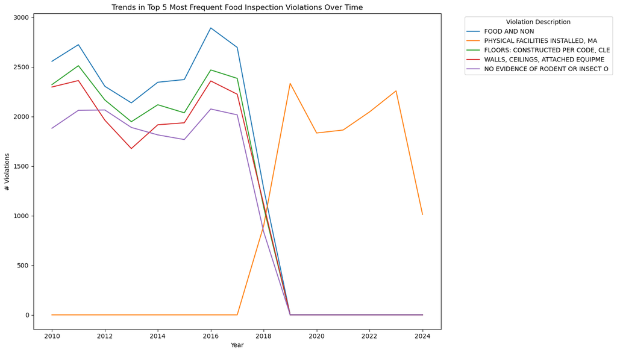

```python
violation_trends = pd.DataFrame({'inspection_year': sorted(failed_inspections_top_5_violations['inspection_year'].unique())})

# Count occurrences of each top 5 violation per year
for violation in top_5_violations:
    violation_rows = failed_inspections_top_5_violations[failed_inspections_top_5_violations['violation_descriptions'].apply(lambda x: violation in x)]
    yearly_counts = violation_rows.groupby('inspection_year').size().reset_index(name=violation)
    violation_trends = pd.merge(violation_trends, yearly_counts, on='inspection_year', how='left')

violation_trends.fillna(0, inplace=True)

# Plot the trends for the top 5 most frequent violations over time
plt.figure(figsize=(14, 8))
for violation in top_5_violations:
    plt.plot(violation_trends['inspection_year'], violation_trends[violation], label=violation[:33])
plt.xlabel('Year')
plt.ylabel('# Violations')
plt.title('Trends in Top 5 Most Frequent Food Inspection Violations Over Time')
plt.legend(title='Violation Description', bbox_to_anchor=(1.05, 1), loc='upper left')
plt.tight_layout()
plt.show()

# We see that among the top 5 common violations, 4 violations completely dropped over time
# and other violation types picked up showing that the data capturing had some change in 2018
# Physical facilities installed picked up in 2018 and then dropped in 2020 (possibly COVID related?) but continued
# over time 2024 data is not full so I expected a drop there in trend
# Top 10 most frequent food inspection violations shows a better trend story
```

```python
top_10_descriptions = pd.DataFrame(description_counts.most_common(10), columns=['Violation Description', 'Count'])
top_10_violations = top_10_descriptions['Violation Description'].tolist()

failed_inspections_top_10_violations = failed_inspections_cleaned[failed_inspections_cleaned['violation_descriptions'].apply(lambda x: any(desc in x for desc in top_10_violations))]
failed_inspections_top_10_violations
```

|  | inspection_id | dba_name | aka_name | license_ | facility_type | risk | address | city | state | zip | ... | latitude | longitude | location | :@computed_region_awaf_s7ux | :@computed_region_6mkv_f3dw | :@computed_region_vrxf_vc4k | :@computed_region_bdys_3d7i | :@computed_region_43wa_7qmu | violation_descriptions | inspection_year |
| --- | --- | --- | --- | --- | --- | --- | --- | --- | --- | --- | --- | --- | --- | --- | --- | --- | --- | --- | --- | --- | --- |
| 20 | 2596274 | STANLEY'S GRILL | STANLEY'S GRILL | 1622034 | Restaurant | Risk 1 (High) | 1543 N ELSTON AVE | CHICAGO | IL | 60642 | ... | 41.9102628778286 | -87.66170856673062 | {'type': 'Point', 'coordinates': [-87.66170856... | 16 | 22620 | 25 | 109 | 46 | [INSECTS, RODENTS, & ANIMALS NOT PRESENT, INSE... | 2024 |
| 34 | 2596211 | VOID CHICAGO | VOID CHICAGO | 2886461 | Restaurant | Risk 1 (High) | 2937 N MILWAUKEE AVE | CHICAGO | IL | 60618 | ... | 41.934705675709715 | -87.7164143561994 | {'type': 'Point', 'coordinates': [-87.71641435... | 15 | 21538 | 22 | 55 | 12 | [ADEQUATE HANDWASHING SINKS PROPERLY SUPPLIED ... | 2024 |
| 36 | 2596234 | UN AMOR | UN AMOR | 2934629 | Restaurant | Risk 1 (High) | 1450 W CHICAGO AVE | CHICAGO | IL | 60642 | ... | 41.89622764512234 | -87.6644351787337 | {'type': 'Point', 'coordinates': [-87.66443517... | 41 | 22620 | 25 | 484 | 41 | [CITY OF CHICAGO FOOD SERVICE SANITATION CERTI... | 2024 |
| 42 | 2596275 | TROHA'S CHICKEN & SHRIMP | TROHA'S CHICKEN & SHRIMP | 1167291 | Restaurant | Risk 1 (High) | 4151 W 26TH ST | CHICAGO | IL | 60623 | ... | 41.84408262179055 | -87.72898370665669 | {'type': 'Point', 'coordinates': [-87.72898370... | 14 | 21569 | 32 | 194 | 28 | [INSECTS, RODENTS, & ANIMALS NOT PRESENT, NON,... | 2024 |
| 52 | 2596203 | ROJO VERDE ANTOJITOS MEXICANOS | ROJO VERDE ANTOJITOS MEXICANOS | 2817884 | Mobile Food Preparer | Risk 2 (Medium) | 2300 S THROOP ST | CHICAGO | IL | 60608 | ... | 41.85045102427 | -87.65879785567869 | {'type': 'Point', 'coordinates': [-87.65879785... | 8 | 14920 | 33 | 126 | 26 | [MANAGEMENT, FOOD EMPLOYEE AND CONDITIONAL EMP... | 2024 |
| ... | ... | ... | ... | ... | ... | ... | ... | ... | ... | ... | ... | ... | ... | ... | ... | ... | ... | ... | ... | ... | ... |
| 273830 | 164252 | SUPER DOG'S SUBMARINES INC | SUPER DOG'S SUBMARINES INC | 2008759 | Restaurant | Risk 2 (Medium) | 1442 W 103RD ST | CHICAGO | IL | 60643 | ... | 41.70685163282266 | -87.65894640986417 | {'type': 'Point', 'coordinates': [-87.65894640... | 33 | 22212 | 71 | 628 | 42 | [NO EVIDENCE OF RODENT OR INSECT OUTER OPENING... | 2010 |
| 273833 | 134239 | BORNIQUEN RESTAURANT | BORNIQUEN RESTAURANT | 32942 | Restaurant | Risk 1 (High) | 1720 N CALIFORNIA AVE | CHICAGO | IL | 60647 | ... | 41.912691923355744 | -87.69720455176802 | {'type': 'Point', 'coordinates': [-87.69720455... | 24 | 22535 | 25 | 300 | 41 | [PREVIOUS MINOR VIOLATION(S) CORRECTED 7, CLEA... | 2010 |
| 273841 | 160209 | CHICAGO SINAI CONGREGATION | CHICAGO SINAI CONGREGATION | 75567 | Daycare (2 - 6 Years) | Risk 1 (High) | 15 W DELAWARE PL | CHICAGO | IL | 60610 | ... | 41.899021699577446 | -87.62892425348232 | {'type': 'Point', 'coordinates': [-87.62892425... | 22 | 14926 | 37 | 230 | 11 | [FOOD AND NON, FOOD AND NON, WALLS, CEILINGS, ... | 2010 |
| 273849 | 104236 | TEMPO CAFE | TEMPO CAFE | 80916 | Restaurant | Risk 1 (High) | 6 E CHESTNUT ST | CHICAGO | IL | 60611 | ... | 41.89843137207629 | -87.6280091630558 | {'type': 'Point', 'coordinates': [-87.62800916... | 22 | 21182 | 37 | 104 | 11 | [NO EVIDENCE OF RODENT OR INSECT OUTER OPENING... | 2010 |
| 273850 | 67738 | MICHAEL'S ON MAIN CAFE | MICHAEL'S ON MAIN CAFE | 2008948 | Restaurant | Risk 1 (High) | 8750 W BRYN WAWR AVE | CHICAGO | IL | 60631 | ... | NaN | NaN | NaN | NaN | NaN | NaN | NaN | NaN | [NO EVIDENCE OF RODENT OR INSECT OUTER OPENING... | 2010 |

46238 rows × 24 columns

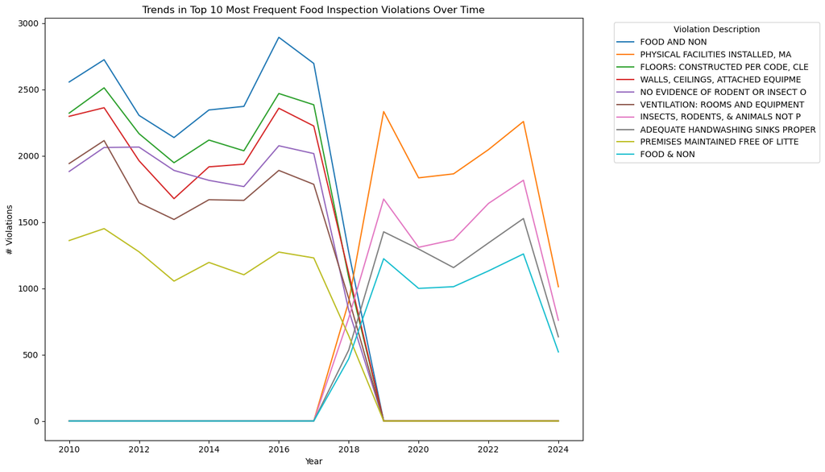

```python
violation_trends = pd.DataFrame({'inspection_year': sorted(failed_inspections_top_10_violations['inspection_year'].unique())})

# Count occurrences of each top 10 violation per year
for violation in top_10_violations:
    violation_rows = failed_inspections_top_10_violations[failed_inspections_top_10_violations['violation_descriptions'].apply(lambda x: violation in x)]
    yearly_counts = violation_rows.groupby('inspection_year').size().reset_index(name=violation)
    violation_trends = pd.merge(violation_trends, yearly_counts, on='inspection_year', how='left')

violation_trends.fillna(0, inplace=True)

# Plot the trends for the top 10 most frequent violations over time
plt.figure(figsize=(14, 8))
for violation in top_10_violations:
    plt.plot(violation_trends['inspection_year'], violation_trends[violation], label=violation[:33])
plt.xlabel('Year')
plt.ylabel('# Violations')
plt.title('Trends in Top 10 Most Frequent Food Inspection Violations Over Time')
plt.legend(title='Violation Description', bbox_to_anchor=(1.05, 1), loc='upper left')
plt.tight_layout()
plt.show()

# As you see the data has some switch change in 2018 causing the trend plot to not show a continous story
# Mentioned in the dataset site too: https://data.cityofchicago.org/Health-Human-Services/Food-Inspections/4ijn-s7e5/about_data
# "Note about 7/1/2018 change to food inspection procedures that affects the data in this dataset: http://bit.ly/2yWd2JB"

# Separate interesting note: During COVID violations were down but ramped up post that
```